# Main Analysis: Attention to Aversive Attributes (Studies 1 and 2)

Brenden Eum

2026-11-06

Correlational analysis of the relationship between attention and choice in a 2-attribute binary choice task where attributes can be positive (P), negative (N), or ambivalent (B). Study 1 (PAS3) and Study 2 (PAS4) use the same task; Study 2 doubled the trials per participant and blocked trial types.

This notebook reads the merged data written by `code/preprocessing/merge_PAS3_PAS4_to_main_data.R` and produces every figure and regression table in the paper. Sections follow the order of the Results:

1. Basic psychometrics
2. Fixation properties
3. Option-level attention
4. Attribute-level attention
5. Range sensitivity

Figures are saved to `paper/figures/`, LaTeX tables to `paper/tables/`, and the statistics quoted in the text of the paper to `paper/text_output/` (one small .tex file each; see the “Text Output” subsections). The last section, “Extra Analyses”, holds analyses that are not in the paper and is switched off by default.

# Preamble

```r
library(tidyverse)
library(glmmTMB)       # frequentist logistic mixed models
library(lme4)          # frequentist linear mixed models
library(brms)          # Bayesian attention-weight and value-sensitivity models
library(bayestestR)    # highest density intervals
library(patchwork)     # combining ggplots into one figure
library(modelsummary)  # regression tables -> LaTeX

# Project utilities. This gives us the plot theme (.myPlot), the Narrow / Wide
# color and shape scales (.wn_colors, .wn_shapes), figure size defaults
# (.figw, .figh, .linewidth), and `paths`.
source(here::here("code/utilities/getAllUtilities.R"))
```

```r
# Set to FALSE for a fast, figures-only pass. The attribute-level figure still
# gets drawn from the cached brms fits in notebooks/brm_fits/ and the cached
# held-out predictions of the Bayesian model. Set to TRUE to
# fit every regression, write the LaTeX tables and the in-text statistics, and
# sample any brms model whose cache is missing (the two attention-weight fits,
# Narrow and Wide, take many hours each the first time; see
# code/fitting/sample_pooled_attention_weights.R to run them from a terminal).
RUN_REGRESSIONS <- FALSE

# Where things live (absolute paths built from config/paths.yaml).
data_dir <- file.path(paths$root, paths$data$processed)
fig_dir  <- file.path(paths$root, paths$paper_figures)
tab_dir  <- file.path(paths$root, paths$paper_tables)
text_dir <- file.path(paths$root, paths$paper_text)
fit_dir  <- file.path(paths$root, paths$notebooks, "brm_fits")
# Caches of the Bayesian model (written by code/fitting/run_bayesian_fits.R).
bayes_dir <- file.path(paths$root, paths$results$cache, "bayesian_model")
for (d in c(fig_dir, tab_dir, text_dir, fit_dir)) dir.create(d, showWarnings = FALSE, recursive = TRUE)

# brms sampling settings (cmdstanr backend).
options(mc.cores = parallel::detectCores())
options(brms.backend = "cmdstanr")
BRMS_CHAINS <- 4
BRMS_SEED   <- 1234

# Keep numbers in the LaTeX tables plain (no siunitx \num{} wrappers).
options("modelsummary_format_numeric_latex" = "plain")

# Weakly informative priors used by every brms model below.
brms_priors <- c(
  prior(normal(0, 2.5), class = "b"),
  prior(normal(0, 2),   class = "Intercept")
)
```

```r
# Layout conventions for every figure:
#   - Narrow vs Wide is shown with color AND marker shape (wn_scales below).
#   - Attribute type (N / B / P) is shown by faceting, so it needs no color.
#   - Study is a title over each half of a combined figure, or a facet strip in
#     figures that have no other faceting.
#   - Size: every figure is 2 * .figw wide and (number of rows) * .figh tall,
#     and all text sizes come from .tick_pt / .title_pt / .strip_pt in
#     MyPlotOptions.
study_labels <- as_labeller(c("1" = "Study 1", "2" = "Study 2"))
type_labels  <- as_labeller(c("N" = "Aversive (N)", "B" = "Ambivalent (B)", "P" = "Appetitive (P)"))

# Strips that say Study 1 / Study 2 (same look as the Study titles).
strip_style <- theme(
  strip.background = element_blank(),
  strip.text       = element_text(size = .title_pt * .fontscale, face = "bold")
)
# Strips that say Aversive / Ambivalent / Appetitive. Small and not bold so
# that all three fit on one line over a facet.
type_strip_style <- theme(
  strip.background = element_blank(),
  strip.text       = element_text(size = .strip_pt * .fontscale)
)
no_strip <- theme(strip.text = element_blank())

# Title over each study's half of a combined figure.
study_title <- theme(plot.title = element_text(hjust = 0.5, face = "bold", size = .title_pt * .fontscale))

# Narrow / Wide colors and markers. Both scales are named "Range", so ggplot
# merges them into a single legend.
wn_scales <- list(
  scale_color_manual(name = "Range", values = .wn_colors),
  scale_shape_manual(name = "Range", values = .wn_shapes)
)

# Nudge Narrow and Wide points apart slightly so they don't sit on top of each
# other (the two ranges share most of their x-values).
wn_dodge <- position_dodge(width = 2)

# x-axis ticks for the N / B / P facets, where x is an attribute value. At this
# text size, labeling every value ("-50 -40 -30 -20 -10") makes the labels run
# into each other, so we label every other value of the Wide range instead.
# With free x scales, ggplot calls this once per facet with that facet's limits.
x_attr_breaks <- function(limits) {
  if (limits[2] < 0) return(c(-50, -30, -10))   # aversive facet
  if (limits[1] > 0) return(c(10, 30, 50))      # appetitive facet
  c(-20, 0, 20)                                 # ambivalent facet
}

# Legends. .myPlot hides legends by default, so every plot with a Range legend
# turns it on with legend_bottom. In a combined figure, guide_area() at the
# bottom collects the identical legends into one centered legend. (The
# installed patchwork, 1.3.0, can't apply themes to a patchwork object under
# ggplot2 4.x, so we don't use `&` to set legend positions.)
legend_bottom <- theme(legend.position = "bottom")
legend_right <- theme(legend.position = "right")

# Point and error-bar sizes for the means +/- SE in every figure. Fitted lines
# use .linewidth from MyPlotOptions.
pt_size      <- 0
pt_linewidth <- 0.7

# In a combined figure, a missing panel (e.g. a fit that was not run) leaves an
# empty space rather than breaking the layout: get_or_spacer(panels, "Data").
get_or_spacer <- function(plots, key) {
  if (is.null(plots[[key]])) plot_spacer() else plots[[key]]
}
```

```r
# Load a cached brms fit if it exists. If it doesn't, fit it only when
# RUN_REGRESSIONS is TRUE; otherwise return NULL so the plotting code can skip
# that panel. brm() itself does the caching through its `file` argument.
load_or_fit <- function(name, ...) {
  file <- file.path(fit_dir, name)
  if (!file.exists(paste0(file, ".rds")) && !RUN_REGRESSIONS) {
    cat("No cached fit for", name, "and RUN_REGRESSIONS is FALSE. Skipping.\n")
    return(NULL)
  }
  brm(..., file = file)
}

# Regression tables. Every regression crosses its predictors with range
# (WNWide) and study (Study2), so each predictor has four coefficients: its
# value at the reference levels (Narrow, Study 1) and its interactions with
# Wide, with Study 2, and with both. Listed as rows, those ran the tables off
# the page, so each predictor gets one row and its four coefficients go in
# four columns. The column headers, keyed by moderator:
range_study_columns <- c("ref"           = "Narrow, Study 1",
                         "WNWide"        = "× Wide",
                         "Study2"        = "× Study 2",
                         "WNWide:Study2" = "× Wide × Study 2")
# The attention-weight models are fit within one range, so they only have study.
study_columns <- c("ref" = "Study 1", "Study2" = "× Study 2")

# Split coefficient names such as "Diff10:WNWide:Study2" into the predictor
# ("Diff10") and its moderators ("WNWide:Study2"). A coefficient with no
# moderator gets "ref"; a moderator on its own (e.g. "WNWide") is the
# intercept's interaction.
split_moderators <- function(term) {
  out <- tibble()
  for (tm in term) {
    pieces <- str_split(tm, ":")[[1]]
    is_mod <- pieces %in% c("WNWide", "Study2")
    out <- bind_rows(out, tibble(
      predictor = if (all(is_mod)) "(Intercept)" else paste(pieces[!is_mod], collapse = ":"),
      moderator = if (any(is_mod)) paste(pieces[is_mod], collapse = ":") else "ref"
    ))
  }
  out
}

# Readable names for the predictors. Values are in units of 10 points and
# dwell times in seconds.
term_labels <- c(
  "(Intercept)"    = "Intercept",
  "Intercept"      = "Intercept",        # brms spells it without parentheses
  "Diff10"         = "Value Diff.",      # left minus right
  "Difficulty10"   = "Abs. Value Diff.", # best minus worst
  "DwellDiff"      = "Net Dwell",        # left minus right
  "RelDiff10_last" = "Value Diff.",      # last-fixated minus other option
  "LastTypeN"      = "Last N",
  "LastTypeB"      = "Last B",
  "fix_typeN"      = "Type N",
  "fix_typeB"      = "Type B",
  "fix_value10"    = "Value",
  "typeN"          = "Type N",
  "typeB"          = "Type B",
  "value10"        = "Value",
  "SV_P"           = "Value Diff. (P)",
  "SV_N"           = "Value Diff. (N)",
  "SV_B"           = "Value Diff. (B)",
  "S2"             = "Study 2"          # Study 2 term on the intercept (pooled attention-weight models)
)

# Label predictors with term_labels, piece by piece for interactions
# ("Diff10:DwellDiff" -> "Value Diff. × Net Dwell"). Attention-weight cells
# read like the figures ("N_neg50" -> "N, -50"), and so do their utilities
# ("U_N_neg50" -> "N, -50"). Anything else passes through.
label_term <- function(term) {
  labels <- c()
  for (tm in term) {
    pieces <- str_split(tm, ":")[[1]]
    for (k in seq_along(pieces)) {
      cell <- str_remove(pieces[k], "^U_")   # a utility is labeled like its cell
      if (pieces[k] %in% names(term_labels)) {
        pieces[k] <- term_labels[[pieces[k]]]
      } else if (str_detect(cell, "^[PNB]_(neg|pos)[0-9]+$")) {
        sign <- if (str_detect(cell, "_neg")) "-" else ""
        pieces[k] <- paste0(str_sub(cell, 1, 1), ", ", sign, str_extract(cell, "[0-9]+$"))
      }
    }
    labels <- c(labels, paste(pieces, collapse = " × "))
  }
  labels
}

# Fixed effects of an lme4 or glmmTMB fit with 95% Wald CIs.
tidy_freq <- function(fit) {
  get_estimates(fit) %>%
    filter(effect == "fixed") %>%
    select(term, estimate, conf.low, conf.high)
}

# Random-effect SDs of an lme4 or glmmTMB fit, named by predictor. modelsummary
# calls them "SD (Diff10 Subject)", and the residual SD of a linear model
# "SD (Observations)".
sds_freq <- function(fit) {
  re  <- get_estimates(fit) %>% filter(str_detect(term, "^SD \\("))
  nms <- re$term %>%
    str_remove("^SD \\(") %>%
    str_remove(" Subject\\)$") %>%
    str_replace("^Observations\\)$", "Residual")
  setNames(re$estimate, nms)
}

# Fit statistics for the bottom of a table: number of trials, marginal and
# conditional R2 (Nakagawa's, as computed by modelsummary through the
# performance package), and how the model was estimated ("Frequentist (lme4)").
gof_freq <- function(fit, estimation) {
  g <- get_gof(fit)
  tibble(
    nobs           = g$nobs,
    r2.marginal    = if (is.null(g$r2.marginal))    NA_real_ else g$r2.marginal,
    r2.conditional = if (is.null(g$r2.conditional)) NA_real_ else g$r2.conditional,
    estimation     = estimation
  )
}

# One model as the columns of a regression table: a modelsummary_list per
# moderator in `columns`, holding that moderator's coefficient for every
# predictor (the rows). The fit statistics go under the first column only.
# Numbers are formatted here, to `digits` decimals, so that one panel of a
# table can show more decimals than another.
table_columns <- function(coefs, gof, columns, digits = 3) {
  coefs <- bind_cols(coefs, split_moderators(coefs$term))
  # `+ 0` turns a rounded negative zero into a plain zero ("0.000", not "-0.000").
  fmt   <- function(x) formatC(round(x, digits) + 0, format = "f", digits = digits)

  out <- list()
  for (m in names(columns)) {
    rows <- coefs %>% filter(moderator == m)
    tidy <- tibble(
      term      = label_term(rows$predictor),
      estimate  = fmt(rows$estimate),
      conf.low  = fmt(rows$conf.low),
      conf.high = fmt(rows$conf.high)
    )
    glance <- if (m == names(columns)[1]) gof else tibble(nobs = NA_real_)
    out[[columns[[m]]]] <- structure(list(tidy = tidy, glance = glance), class = "modelsummary_list")
  }
  out
}
```

```r
# The same for an lme4 / glmmTMB fit crossed with range and study, which is
# every frequentist model in the paper.
freq_columns <- function(fit, estimation, digits = 3) {
  table_columns(tidy_freq(fit), gof_freq(fit, estimation), range_study_columns, digits)
}

# Table note with the random-effect SDs. `sds` is a list with one named vector
# per panel (from sds_freq or sds_brms), named by panel ("Panel A") or unnamed
# for a table with one model. Entries are separated by semicolons because cell
# labels ("N, -30") have commas in them.
sd_note <- function(sds, intro = "Random-effect SDs across subjects.") {
  parts <- c()
  for (p in seq_along(sds)) {
    x       <- sds[[p]]
    entries <- paste(label_term(names(x)), formatC(x, format = "f", digits = 3), collapse = "; ")
    panel   <- names(sds)[p]
    if (is.null(panel) || panel == "") {
      parts <- c(parts, paste0(entries, "."))
    } else {
      parts <- c(parts, paste0(panel, ": ", entries, "."))
    }
  }
  paste("\\textit{Note.}", intro, paste(parts, collapse = " "))
}

# Write a regression table to paper/tables/<name>.tex as a booktabs tabular
# plus an optional note under it (so it can be \input into a table environment
# in the paper), and echo the LaTeX so it also shows up in the knitted
# notebook. `tab` is either one model's columns (from table_columns) or a named
# list of them, one per panel ("Panel A: Choice" = ...), which modelsummary
# stacks with shape = "rbind". Intervals go on a line of their own under each
# estimate, unless `ci_inline` is TRUE, which puts them next to the estimate
# (halving the length of a table that has room to spare in width).
# `coef_order` (row labels, in order) fixes the row order when the models in a
# table have different rows; otherwise rows follow their first appearance.
save_tex <- function(tab, name, note = NULL, ci_inline = FALSE, coef_order = NULL) {
  file      <- file.path(tab_dir, paste0(name, ".tex"))
  coef_map  <- if (is.null(coef_order)) NULL else setNames(coef_order, coef_order)
  is_panels <- !inherits(tab[[1]], "modelsummary_list")
  if (ci_inline) {
    estimate  <- "{estimate} [{conf.low}, {conf.high}]"
    statistic <- NULL
  } else {
    estimate  <- "{estimate}"
    statistic <- "conf.int"
  }

  # The only fit statistics we report (in this order). "estimation" is the
  # label from gof_freq / gof_brms, so the reader can tell which models were
  # fit by maximum likelihood and which by MCMC.
  gof_map <- list(
    list(raw = "nobs",           clean = "Num.Obs.",   fmt = 0),
    list(raw = "r2.marginal",    clean = "R2 Marg.",   fmt = 3),
    list(raw = "r2.conditional", clean = "R2 Cond.",   fmt = 3),
    list(raw = "estimation",     clean = "Estimation", fmt = identity)
  )
  if (is_panels) {
    tex <- modelsummary(tab, shape = "rbind", estimate = estimate, statistic = statistic,
                        gof_map = gof_map, coef_map = coef_map, output = "latex_tabular")
  } else {
    tex <- modelsummary(tab, estimate = estimate, statistic = statistic,
                        gof_map = gof_map, coef_map = coef_map, output = "latex_tabular")
  }
  tex   <- strsplit(paste(as.character(tex), collapse = "\n"), "\n")[[1]]
  n_col <- nchar(str_match(tex[1], "\\{(l+)\\}")[, 2])

  # modelsummary's bare tabular has no horizontal rules and writes a panel's
  # title into every column. Go through it line by line and add the usual
  # booktabs rules, one title per panel, and a single Estimation label per
  # model spread over all the coefficient columns.
  out <- c()
  for (i in seq_along(tex)) {
    line  <- tex[i]
    cells <- str_trim(str_split(str_remove(str_trim(line), "\\\\\\\\$"), "&")[[1]])
    if (str_detect(line, "^\\\\begin\\{tabular\\}")) {
      out <- c(out, line, "\\toprule")
    } else if (i == 2) {
      # the header; a panel title below it brings its own rule
      out <- c(out, line)
      if (!is_panels) out <- c(out, "\\midrule")
    } else if (str_detect(line, "^\\\\end\\{tabular\\}")) {
      out <- c(out, "\\bottomrule", line)
    } else if (length(cells) == n_col && cells[1] != "" && all(cells == cells[1])) {
      out <- c(out, "\\midrule", paste0("\\multicolumn{", n_col, "}{l}{\\textit{", cells[1], "}} \\\\"))
    } else if (str_detect(line, "^Num.Obs.")) {
      out <- c(out, if (is_panels) "\\addlinespace" else "\\midrule", line)
    } else if (str_detect(line, "^R2 ")) {
      out <- c(out, paste0("$R^2$", str_remove(line, "^R2")))
    } else if (str_detect(line, "^Estimation")) {
      out <- c(out, paste0("Estimation & \\multicolumn{", n_col - 1, "}{l}{", cells[2], "} \\\\"))
    } else {
      out <- c(out, line)
    }
  }

  # The note spans the text width, in script size, under the table.
  if (!is.null(note)) {
    out <- c(out, "\\par\\medskip",
             paste0("\\begin{minipage}{\\linewidth}\\scriptsize ", note, "\\end{minipage}"))
  }

  writeLines(out, file)
  cat(out, sep = "\n")
}

# Population-level effects of a brms fit as a tidy table: posterior median and
# 95% HDI for every b_ parameter (the "b_" prefix is dropped from the names).
tidy_brms <- function(fit) {
  draws <- as_draws_df(fit, variable = "^b_", regex = TRUE)
  pars  <- grep("^b_", names(draws), value = TRUE)

  out <- tibble()
  for (par in pars) {
    x <- draws[[par]]
    h <- bayestestR::hdi(x, ci = 0.95)
    out <- bind_rows(out, tibble(
      term = str_remove(par, "^b_"), estimate = median(x),
      conf.low = h$CI_low, conf.high = h$CI_high
    ))
  }
  out
}

# Posterior medians of the subject-level SDs of a brms fit, named by predictor
# like sds_freq ("sd_Subject__SV_P" -> "SV_P").
sds_brms <- function(fit) {
  draws <- as_draws_df(fit, variable = "^sd_", regex = TRUE)
  pars  <- grep("^sd_", names(draws), value = TRUE)
  sds   <- c()
  for (par in pars) {
    sds[str_remove(par, "^sd_Subject__")] <- median(draws[[par]])
  }
  sds[cell_order(names(sds))]   # same order as the table rows
}

# Fit statistics of a brms fit, like gof_freq. modelsummary would compute LOO
# for these big fits, which takes forever, so we compute the Bayesian R2
# ourselves: conditional on the subject effects, and marginal (without them).
# 1,000 evenly spaced posterior draws are plenty for a median.
gof_brms <- function(fit, estimation = "Bayesian (brms)") {
  ids <- round(seq(1, ndraws(fit), length.out = 1000))
  tibble(
    nobs           = nrow(fit$data),
    r2.marginal    = median(bayes_R2(fit, re_formula = NA, summary = FALSE, draw_ids = ids)),
    r2.conditional = median(bayes_R2(fit, summary = FALSE, draw_ids = ids)),
    estimation     = estimation
  )
}
```

```r
# Order for the attention-weight tables: the intercept and other predictors
# as they come, then the cells sorted like the figures, by type (N, B, P) and
# then by value. `pred` are predictor names such as "SV_P", "N_neg50" or
# "U_N_neg50" (a utility sorts like its cell).
cell_order <- function(pred) {
  pred    <- str_remove(pred, "^U_")
  is_cell <- str_detect(pred, "^[PNB]_(neg|pos)[0-9]+$")
  type    <- match(str_sub(pred, 1, 1), c("N", "B", "P"))
  value   <- as.numeric(str_extract(pred, "[0-9]+$")) * if_else(str_detect(pred, "_neg"), -1, 1)
  # order() is stable, so the non-cells (all ties here) keep their order
  order(is_cell, ifelse(is_cell, type, 0), ifelse(is_cell, value, 0))
}

# Rows of a tidy coefficient table in that order.
order_cells <- function(coefs) {
  coefs[cell_order(split_moderators(coefs$term)$predictor), ]
}
```

```r
# Statistics quoted in the text of the paper. Each one is a short LaTeX math
# snippet saved to paper/text_output/<name>.tex, which main.tex pulls in with
# \input{text_output/<name>} in place of the numbers. write.text() (from
# code/utilities) writes the string with no trailing newline, so \input adds
# no stray space inside a parenthesis.
# Notation: the study (or a contrast between studies) is always the subscript;
# the superscript is for everything else (attribute type, range, predictor...).
save_text <- function(text, name) {
  write.text(text, file.path(text_dir, paste0(name, ".tex")))
  cat(text, "\n")
}

# "0.013\ [0.003, 0.023]": an estimate with its 95% interval.
fmt_ci <- function(est, lo, hi, digits = 3) {
  z <- function(x) round(x, digits) + 0   # so a bound that rounds to 0 prints as 0.000, not -0.000
  sprintf("%.*f\\ [%.*f, %.*f]", digits, z(est), digits, z(lo), digits, z(hi))
}

# p-values: three decimals, or scientific notation below .001 (e.g. "p = 3e-15").
fmt_p <- function(p) {
  if (p < 0.001) paste0("p = ", formatC(p, format = "e", digits = 0)) else sprintf("p = %.3f", p)
}

# Estimate and 95% Wald CI of a linear combination of fixed effects, e.g. the
# Study 2 slope = b_slope + b_slope:Study2. `terms` are coefficient names and
# `weights` their multipliers (by default they are just added up). lmer
# returns fixef() and vcov() directly; glmmTMB wraps them in a list with a
# $cond element. With tens of thousands of trials the 1.96 normal cutoff gives
# the same intervals as the tables (to three decimals).
coef_ci <- function(fit, terms, weights = rep(1, length(terms))) {
  b <- fixef(fit); if (is.list(b)) b <- b$cond
  V <- vcov(fit);  if (is.list(V)) V <- V$cond
  V <- as.matrix(V)
  est <- sum(weights * b[terms])
  se  <- sqrt(as.numeric(t(weights) %*% V[terms, terms] %*% weights))
  c(estimate = est, lo = est - 1.96 * se, hi = est + 1.96 * se)
}

# The same, already formatted, so one snippet is one line of code.
fmt_coef <- function(fit, terms, weights = rep(1, length(terms)), digits = 3) {
  ci <- coef_ci(fit, terms, weights)
  fmt_ci(ci[["estimate"]], ci[["lo"]], ci[["hi"]], digits)
}

# Posterior median and 95% HDI of a vector of draws, formatted like fmt_ci.
fmt_post <- function(draws, digits = 3) {
  h <- bayestestR::hdi(draws, ci = 0.95)
  fmt_ci(median(draws), h$CI_low, h$CI_high, digits)
}

# t-test between two vectors of subject means, in the format
# "$\Delta^{sup}_{sub} = 2.59$, $d = 0.39$, $t(1298.3) = 7.1$, $p = 2e-12$",
# where `sup` says what is compared (e.g. "\\text{Wide - Narrow}") and `sub`
# the study (e.g. "Study 1"; left out if NULL). Welch's test by default;
# paired = TRUE when both vectors come from the same subjects in the same
# order. Cohen's d uses the pooled SD (Welch) or the SD of the paired
# differences. `unit` is appended to Delta (e.g. "\\ \\text{s}").
fmt_ttest <- function(x, y, sup, sub = NULL, unit = "", paired = FALSE, digits = 2) {
  tt    <- t.test(x, y, paired = paired)
  delta <- mean(x) - mean(y)
  if (paired) {
    d <- delta / sd(x - y)
  } else {
    sp <- sqrt(((length(x) - 1) * var(x) + (length(y) - 1) * var(y)) / (length(x) + length(y) - 2))
    d  <- delta / sp
  }
  df   <- tt$parameter
  df   <- if (df == round(df)) sprintf("%d", df) else sprintf("%.1f", df)   # paired tests: whole df
  name <- paste0("\\Delta^{", sup, "}", if (!is.null(sub)) paste0("_{\\text{", sub, "}}"))
  sprintf("$%s = %.*f%s$, $d = %.2f$, $t(%s) = %.1f$, $%s$",
          name, digits, delta, unit, d, df, tt$statistic, fmt_p(tt$p.value))
}
```

# Data

```r
pas_raw  <- read_csv(file.path(data_dir, "main_data.csv"),      show_col_types = FALSE)
long_raw <- read_csv(file.path(data_dir, "main_data_long.csv"), show_col_types = FALSE)
```

## Trial level

One row per trial. `Subject` is already unique across studies (e.g. “S1_5” vs “S2_5”), so it can be used directly as the grouping variable everywhere.

```r
pas <- pas_raw %>%
  mutate(
    WN      = factor(WN,  levels = c("Narrow", "Wide")),   # Narrow is the reference level
    BPN     = factor(BPN, levels = c("PN", "PB", "NB")),
    ChooseL = as.integer(ChooseL),                         # TRUE/FALSE -> 1/0
    Correct = as.integer(Correct),
    Difficulty = abs(Diff),                                # best minus worst option value
    # Regressions use value in units of 10 points, matching the paper's SV_* convention.
    Diff10       = Diff / 10,
    Difficulty10 = Difficulty / 10
  )
```

## Box level

Each trial has four boxes (left/right option x top/bottom attribute). Stack them so there is one row per box, with the box’s attribute type, value, and dwell time. Left boxes get a side sign of +1 (looking there should push choice toward “left”), right boxes -1.

```r
mk_box <- function(df, box, side_sign, type_col, val_col, dwell_col) {
  df %>%
    transmute(
      Study, Subject, Trial, WN, ChooseL,
      box       = box,
      side_sign = side_sign,
      type      = .data[[type_col]],
      value     = .data[[val_col]],
      dwell     = .data[[dwell_col]]
    )
}

boxlong <- bind_rows(
  mk_box(pas, "LT",  1, "AttT", "VLT", "DwellLT"),
  mk_box(pas, "LB",  1, "AttB", "VLB", "DwellLB"),
  mk_box(pas, "RT", -1, "AttT", "VRT", "DwellRT"),
  mk_box(pas, "RB", -1, "AttB", "VRB", "DwellRB")
) %>%
  mutate(
    type = factor(type, levels = c("P", "N", "B")),
    # Signed dwell: seconds, positive if it should push choice toward this box's side.
    signed_dwell = side_sign * dwell,
    # Signed value, in units of 10 points.
    signed_value = side_sign * value / 10,
    # Cell label for (type x value), e.g. "N_neg10", "P_pos5". Used to name the
    # attention-weight coefficients.
    cell = paste0(type, "_", if_else(value < 0, "neg", "pos"), abs(value))
  )
```

## Fixation level

One row per fixation (mouse hover). `FixDur` is in ms. Tag each fixation with the value and type of the box it landed on.

```r
long <- long_raw %>%
  mutate(
    WN = factor(WN, levels = c("Narrow", "Wide")),
    fix_value = case_when(
      FixROI == "LT" ~ VLT, FixROI == "RT" ~ VRT,
      FixROI == "LB" ~ VLB, FixROI == "RB" ~ VRB
    ),
    fix_value10 = fix_value / 10,
    fix_type = factor(if_else(FixROI %in% c("LT", "RT"), AttT, AttB),
                      levels = c("P", "N", "B")),
    fix_side = if_else(FixROI %in% c("LT", "LB"), "L", "R")
  )
```

### First and last fixation of each trial

Needed for the first-fixation and last-fixation analyses. Trials with no fixation record (about 500 per study) get NA here and drop out of those analyses.

```r
first_last <- long %>%
  arrange(Study, Subject, Trial, FixNum) %>%
  group_by(Study, Subject, Trial) %>%
  summarise(
    FirstSide = first(fix_side),
    LastSide  = last(fix_side),
    LastType  = last(fix_type),
    .groups   = "drop"
  )

pas <- pas %>%
  left_join(first_last, by = c("Study", "Subject", "Trial")) %>%
  mutate(
    # Was the first fixation to the better option? Undefined when the options tie.
    BestSide     = case_when(Diff > 0 ~ "L", Diff < 0 ~ "R", TRUE ~ NA_character_),
    FirstFixBest = as.integer(FirstSide == BestSide),
    # Did the subject choose the option they looked at last?
    ChooseLast = as.integer((LastSide == "L") == (ChooseL == 1)),
    # Value difference from the point of view of the last-fixated option
    # (last-fixated option minus the other one).
    RelDiff_last   = if_else(LastSide == "L", VL - VR, VR - VL),
    RelDiff10_last = RelDiff_last / 10
  )
```

### Fixation counts per box

For the share-of-fixations analysis: how many of a trial’s fixations went to each box. Boxes that were never fixated get a count of 0.

```r
fix_counts <- long %>% count(Study, Subject, Trial, FixROI, name = "n_fix")
fix_total  <- long %>% count(Study, Subject, Trial, name = "n_trial")

box_grid <- boxlong %>%
  transmute(Study, Subject, Trial, WN, FixROI = box, type, value, value10 = value / 10) %>%
  left_join(fix_counts, by = c("Study", "Subject", "Trial", "FixROI")) %>%
  left_join(fix_total,  by = c("Study", "Subject", "Trial")) %>%
  filter(!is.na(n_trial)) %>%                 # trials with no fixation record drop out
  mutate(
    n_fix = replace_na(n_fix, 0L),
    share = n_fix / n_trial
  )
```

# Basic Psychometrics

Choice as a function of the value difference between options, and response time as a function of difficulty (best minus worst option value). In every figure, points are means across participants with standard errors (each participant contributes one mean per x-value first, then we average over participants).

```r
pdata_choice <- pas %>%
  group_by(Study, Subject, WN, Diff) %>%
  summarise(y_subject = mean(ChooseL), .groups = "drop") %>%
  group_by(Study, WN, Diff) %>%
  summarise(y = mean(y_subject), se = sd(y_subject) / sqrt(n()), .groups = "drop")

p_choice <- ggplot(pdata_choice, aes(x = Diff, y = y, color = WN, shape = WN)) +
  facet_wrap(~ Study, labeller = study_labels) +
  geom_vline(xintercept = 0,   linetype = "dotted", color = "grey50") +
  geom_hline(yintercept = 0.5, linetype = "dotted", color = "grey50") +
  geom_line(linewidth = .linewidth, position = wn_dodge) +
  geom_pointrange(aes(ymin = y - se, ymax = y + se), size = pt_size, linewidth = .linewidth,
                  position = wn_dodge) +
  #stat_smooth(method = "glm", method.args = list(family = "binomial"), se = FALSE, linewidth = .linewidth) +
  wn_scales +
  labs(x = "Value Difference (L - R)", y = "Pr(Choose Left)") +
  .myPlot + strip_style + legend_right +
  scale_y_continuous(breaks = seq(0, 1, by = 0.5), labels = scales::percent_format(accuracy = 1))
```

```r
pdata_rt <- pas %>%
  group_by(Study, Subject, WN, Difficulty) %>%
  summarise(y_subject = mean(RT), .groups = "drop") %>%
  group_by(Study, WN, Difficulty) %>%
  summarise(y = mean(y_subject), se = sd(y_subject) / sqrt(n()), .groups = "drop")

p_rt <- ggplot(pdata_rt, aes(x = Difficulty, y = y, color = WN, shape = WN)) +
  facet_wrap(~ Study, labeller = study_labels) +
  geom_line(linewidth = .linewidth, position = wn_dodge) +
  geom_pointrange(aes(ymin = y - se, ymax = y + se), size = pt_size, linewidth = .linewidth, position = wn_dodge) +
  #stat_smooth(method = "lm", se = FALSE, linewidth = .linewidth) +
  wn_scales +
  labs(x = "Best - Worst Value", y = "Response Time (s)") +
  .myPlot + strip_style + no_strip + legend_right +
  coord_cartesian(ylim = c(4, 10))
```

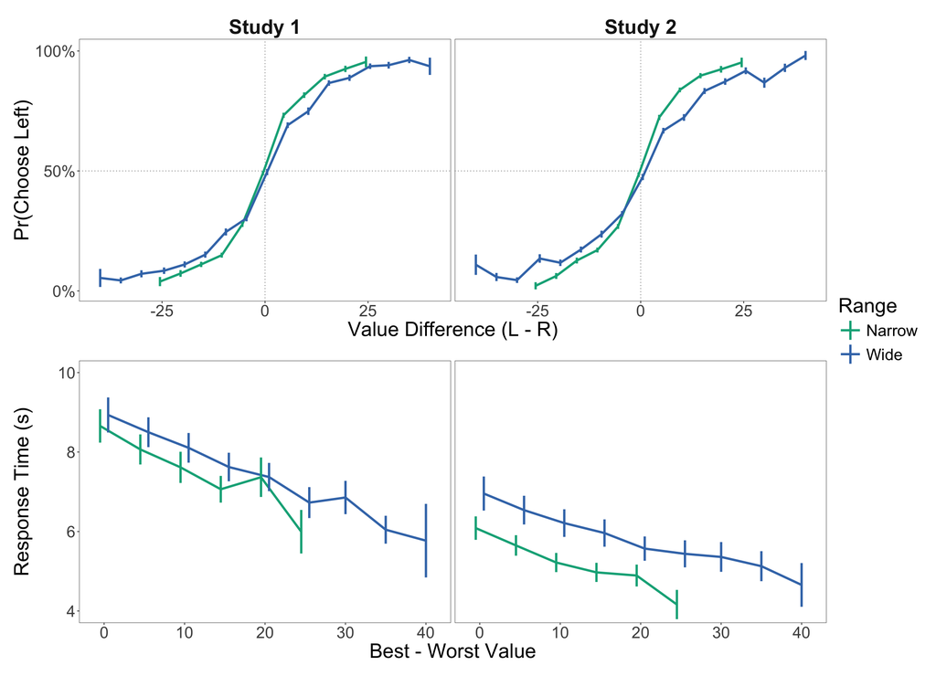

```r
# 2 rows (choice, RT) x 2 columns (Study 1, Study 2).
fig_psych <- (p_choice / p_rt) +
  plot_layout(guides = "collect")

ggsave(file.path(fig_dir, "basic_psychometrics.pdf"), fig_psych, width = 2 * .figw, height = 2 * .figh)
fig_psych
```

## Range Sensitivity Simulations

The paper argues that the lower value sensitivity of the Wide condition is what models of value normalization predict (Supplementary “Range Sensitivity Simulations”). Here we simulate choices from four such models on two hypothetical studies built from our own trials, then run the same choice regression on each simulated data set. Every model maps a box’s objective value $a$ to a subjective value $f(a)$ through the context of its attribute type, an option’s subjective value is the sum of its two boxes, and choice is a logit on the left minus right subjective value. Each model lives in its own script under `code/simulation/`, with the shared pieces (trial sets, participants, choice rule) in `simulate_normalized_choices.R`:

- **Range normalization** (`simulate_range_normalization.R`): $f(a) = (a - \min) / (\max - \min)$, where min and max are the smallest and largest value the type takes in the participant’s range condition.
- **Context divisive normalization** (`simulate_context_divisive_normalization.R`): $f(a) = a / (\sigma_h + \omega \, \overline{|a|})$, dividing by the mean magnitude of the type’s values in the range condition ($\sigma_h = 5$, $\omega = 1$).
- **Trial divisive normalization** (`simulate_trial_divisive_normalization.R`): $f(a_L) = a_L / (\sigma_h + \omega (|a_L| + |a_R|))$, dividing by the two values the attribute takes on the current trial (same parameters).
- **Rank normalization** (`simulate_rank_normalization.R`): $f(a) = (\text{rank}(a) - 1) / 5$, the rank of the value among the six values of its type in the range condition.

Each hypothetical study is one range condition with 60 real trials (20 per block type, drawn from both studies) and 260 participants, matching Study 2. Participants differ only in inverse temperature (uniform from 1 to 5); there is no side bias, nothing about a participant depends on their condition, and all four models use the same participants, trials, and random draws. Because every participant sees the same 60 trials, a value difference that occurs on only one or two trials reflects the makeup of those trials, which is why the curves of the two divisive models are jagged.

```r
source(here::here("code/simulation/simulate_range_normalization.R"))
source(here::here("code/simulation/simulate_context_divisive_normalization.R"))
source(here::here("code/simulation/simulate_trial_divisive_normalization.R"))
source(here::here("code/simulation/simulate_rank_normalization.R"))

sim_design       <- design_values(pas)       # the six values per type and condition
sim_trials       <- make_trial_sets(pas)     # 60 real trials per condition
sim_participants <- draw_participants()      # 260 per condition

# One simulation function per model, named as the figure will label them.
sim_models <- list(
  "Range Normalization"            = simulate_range_normalization,
  "Context Divisive Normalization" = simulate_context_divisive_normalization,
  "Trial Divisive Normalization"   = simulate_trial_divisive_normalization,
  "Rank Normalization"             = simulate_rank_normalization
)

sim_data <- list()
for (m in names(sim_models)) {
  sim_data[[m]] <- sim_models[[m]](sim_trials, sim_participants, sim_design) %>% mutate(Model = m)
}
sim_data <- bind_rows(sim_data) %>% mutate(Model = factor(Model, levels = names(sim_models)))
```

The regression is the choice model of the Regressions section below without the study terms. The quantity of interest is the `Diff10:WNWide` interaction, the Wide minus Narrow difference in slope. Each panel is annotated with the condition that has the steeper slope and the p-value of that difference, rounded to three decimals (in scientific notation when it is below .001). These four fits take a few seconds, so they run on every pass.

```r
sim_stats <- data.frame()
for (m in names(sim_models)) {
  fit <- glmmTMB(ChooseL ~ Diff10 * WN + (1 + Diff10 | Subject),
                 data = filter(sim_data, Model == m), family = binomial)
  coefs <- summary(fit)$coefficients$cond
  sim_stats <- rbind(sim_stats, data.frame(
    Model        = m,
    slope_narrow = coefs["Diff10", "Estimate"],
    slope_wide   = coefs["Diff10", "Estimate"] + coefs["Diff10:WNWide", "Estimate"],
    interaction  = coefs["Diff10:WNWide", "Estimate"],
    se           = coefs["Diff10:WNWide", "Std. Error"],
    p            = coefs["Diff10:WNWide", "Pr(>|z|)"]
  ))
}
# Annotation in the figure: which condition is steeper, and the p-value of the
# difference in slope (the Diff10:WNWide interaction). fmt_p (text-helpers)
# gives three decimals, or scientific notation when p is below .001 and three
# decimals would read 0.000 (e.g. "p = 8e-15"). All four models have a steeper
# Narrow slope; the direction word follows the sign of the interaction so that
# a label can never state the wrong direction.
sim_stats$label <- NA_character_
for (i in 1:nrow(sim_stats)) {
  steeper <- ifelse(sim_stats$interaction[i] < 0, "Narrow steeper than Wide", "Wide steeper than Narrow")
  sim_stats$label[i] <- paste0(steeper, " (", fmt_p(sim_stats$p[i]), ")")
}
sim_stats$Model <- factor(sim_stats$Model, levels = names(sim_models))
sim_stats
```

```
##                            Model slope_narrow slope_wide interaction         se
## 1            Range Normalization    1.0117932  0.6892963  -0.3224969 0.03786354
## 2 Context Divisive Normalization    1.4381834  0.8680188  -0.5701646 0.04055038
## 3   Trial Divisive Normalization    0.8336092  0.4224139  -0.4111953 0.02720351
## 4             Rank Normalization    0.9516664  0.6367706  -0.3148958 0.03593959
##              p                                label
## 1 1.632472e-17 Narrow steeper than Wide (p = 2e-17)
## 2 6.627848e-45 Narrow steeper than Wide (p = 7e-45)
## 3 1.279451e-51 Narrow steeper than Wide (p = 1e-51)
## 4 1.921399e-18 Narrow steeper than Wide (p = 2e-18)
```

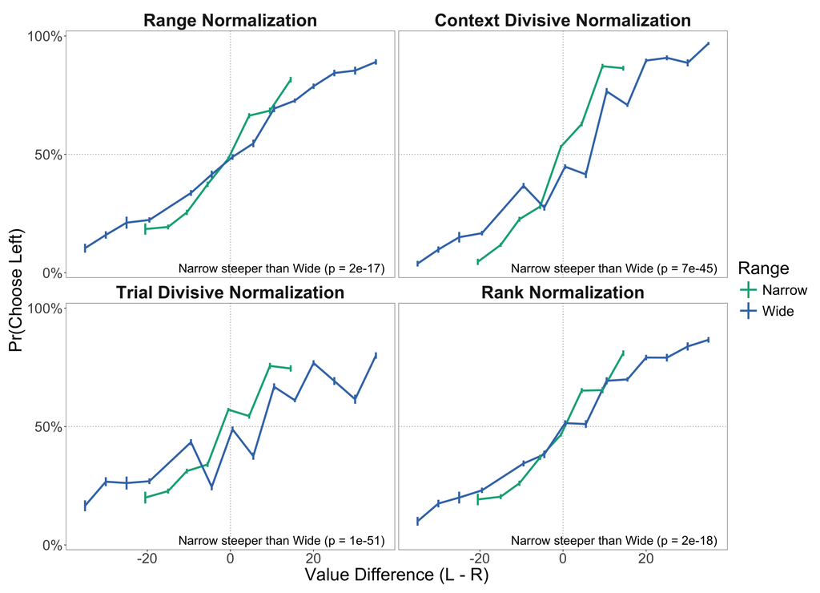

```r
# 2 x 2 panels, one per model, formatted like the choice row of the basic
# psychometrics figure. Points are means across simulated participants with
# standard errors; the annotation in the bottom right of each panel says which
# condition is steeper and the p-value of the difference in slope.
pdata_sim <- sim_data %>%
  group_by(Model, Subject, WN, Diff) %>%
  summarise(y_subject = mean(ChooseL), .groups = "drop") %>%
  group_by(Model, WN, Diff) %>%
  summarise(y = mean(y_subject), se = sd(y_subject) / sqrt(n()), .groups = "drop")

fig_range_sim <- ggplot(pdata_sim, aes(x = Diff, y = y, color = WN, shape = WN)) +
  facet_wrap(~ Model, ncol = 2) +
  geom_vline(xintercept = 0,   linetype = "dotted", color = "grey50") +
  geom_hline(yintercept = 0.5, linetype = "dotted", color = "grey50") +
  geom_line(linewidth = .linewidth, position = wn_dodge) +
  geom_pointrange(aes(ymin = y - se, ymax = y + se), size = pt_size, linewidth = .linewidth,
                  position = wn_dodge) +
  geom_text(data = sim_stats, aes(x = Inf, y = -Inf, label = label), inherit.aes = FALSE,
            hjust = 1.05, vjust = -0.6, size = .strip_pt * .fontscale / .pt) +
  wn_scales +
  labs(x = "Value Difference (L - R)", y = "Pr(Choose Left)") +
  .myPlot + strip_style + legend_right +
  scale_y_continuous(breaks = seq(0, 1, by = 0.5), labels = scales::percent_format(accuracy = 1))

ggsave(file.path(fig_dir, "range_sensitivity_simulations.pdf"), fig_range_sim, width = 2 * .figw, height = 2 * .figh)
fig_range_sim
```

## Regressions

One model per outcome, pooled across both studies. Choice on value difference, and RT on difficulty, each interacted with range and with study. Study 1 and Narrow are the reference levels, so a `Study2` term is the Study 2 minus Study 1 difference (at Narrow) and a `WNWide` term is the Wide minus Narrow difference (in Study 1); the Study 2 version of any effect is the Study 1 coefficient plus its `:Study2` interaction. Random intercepts and slopes by subject. In the RT model the intercept-slope correlation went to -1 when estimated (a singular fit), so those random effects are uncorrelated.

```r
if (RUN_REGRESSIONS) {
  d <- pas %>% mutate(Study = factor(Study))   # 1 / 2 -> "1" / "2", reference "1"

  fit_choice <- glmmTMB(
    ChooseL ~ Diff10 * WN * Study + (1 + Diff10 | Subject),
    data = d, family = binomial
  )

  fit_rt <- lmer(
    RT ~ Difficulty10 * WN * Study + (1 + Difficulty10 || Subject),
    data = d, control = lmerControl(optimizer = "bobyqa")
  )

  # One panel per model, with the random-effect SDs in the note.
  tab <- list(
    "Panel A: Choice" = freq_columns(fit_choice, "Frequentist (glmmTMB)"),
    "Panel B: RT"     = freq_columns(fit_rt,     "Frequentist (lme4)")
  )
  note <- sd_note(list("Panel A" = sds_freq(fit_choice), "Panel B" = sds_freq(fit_rt)))
  save_tex(tab, "basic_psychometrics", note)
}
```

## Text Output

The statistics quoted in the Basic Psychometrics paragraph of the paper, one chunk per snippet (see `save_text` in the preamble).

```r
if (RUN_REGRESSIONS) {
  # Study 2 minus Study 1 response time (s) from the pooled RT model. Study 1
  # and Narrow are the reference levels, so this is the difference at Narrow
  # and a value difference of 0.
  save_text(paste0("$\\Delta_{\\text{Study 2 - Study 1}} = ", fmt_coef(fit_rt, "Study2"), "\\ \\text{s}$"),
            "rt_study_level")
}
```

```r
if (RUN_REGRESSIONS) {
  # Study 2 minus Study 1 difference in the RT slope on difficulty (s per 10
  # points): the Difficulty x Study interaction.
  save_text(paste0("$\\beta^{\\text{Difficulty}}_{\\text{Study 2 - Study 1}} = ", fmt_coef(fit_rt, "Difficulty10:Study2"), "$"),
            "rt_study_slope")
}
```

```r
if (RUN_REGRESSIONS) {
  # Wide minus Narrow response time (s) per study. WNWide is the Study 1
  # difference; Study 2 adds the WNWide:Study2 interaction.
  save_text(paste0(
    "$\\Delta^{\\text{Wide - Narrow}}_{\\text{Study 1}} = ", fmt_coef(fit_rt, "WNWide"), "$; ",
    "$\\Delta^{\\text{Wide - Narrow}}_{\\text{Study 2}} = ", fmt_coef(fit_rt, c("WNWide", "WNWide:Study2")), "$"
  ), "rt_range_level")
}
```

```r
if (RUN_REGRESSIONS) {
  # Is Study 2 faster only because its subjects had more practice (60 trials
  # vs 30)? Mean RT per subject over a window of trial numbers. Picking by
  # trial number means trials dropped in preprocessing are missing the same
  # way in both studies.
  subj_rt <- function(s, trials) {
    pas %>%
      filter(Study == s, Trial %in% trials) %>%
      group_by(Subject) %>%
      summarise(rt = mean(RT), .groups = "drop") %>%
      pull(rt)
  }
  rt_s1       <- subj_rt(1, 1:30)   # all of Study 1
  rt_s2_early <- subj_rt(2, 1:30)
  rt_s2_late  <- subj_rt(2, 31:60)

  # Welch t-tests, Study 2 minus Study 1 (s): Study 2's later trials first,
  # then the trials where both studies had the same amount of practice.
  save_text(paste(
    fmt_ttest(rt_s2_late,  rt_s1, sup = "\\text{Trials 31--60 vs. 1--30}",
              sub = "Study 2 - Study 1", unit = "\\ \\text{s}"),
    fmt_ttest(rt_s2_early, rt_s1, sup = "\\text{Trials 1--30 vs. 1--30}",
              sub = "Study 2 - Study 1", unit = "\\ \\text{s}"),
    sep = "; "), "rt_familiarity")
}
```

# Fixation Properties

How attention was allocated before asking how it relates to choice: where the first fixation went, how long individual fixations lasted, and how often each box was revisited.

```r
# Pr(first fixation lands on the better option), by difficulty.
pdata_first <- pas %>%
  filter(!is.na(FirstFixBest)) %>%
  group_by(Study, Subject, WN, Difficulty) %>%
  summarise(y_subject = mean(FirstFixBest), .groups = "drop") %>%
  group_by(Study, WN, Difficulty) %>%
  summarise(y = mean(y_subject), se = sd(y_subject) / sqrt(n()), .groups = "drop")

# One plot per study; the "Study s" title goes over each half of the combined
# figure. coord_cartesian() comes after .myPlot so that it isn't overwritten.
p_first <- list()
for (s in 1:2) {
  p_first[[s]] <- ggplot(pdata_first %>% filter(Study == s),
                         aes(x = Difficulty, y = y, color = WN, shape = WN)) +
    geom_hline(yintercept = 0.5, linetype = "dotted", color = "grey50") +
    geom_line(linewidth = .linewidth, position = wn_dodge) +
    geom_pointrange(aes(ymin = y - se, ymax = y + se), size = pt_size, linewidth = .linewidth, position = wn_dodge) +
    #stat_smooth(method = "glm", method.args = list(family = "binomial"), se = FALSE, linewidth = .linewidth) +
    wn_scales +
    labs(x = "Best - Worst Value", y = "Pr(First Fixation to Best)", title = paste("Study", s)) +
    .myPlot + strip_style + study_title + legend_right + theme(legend.direction = "vertical") +
    coord_cartesian(ylim = c(0, 1), xlim = c(0, 40)) +
    scale_y_continuous(breaks = seq(0, 1, by = 0.5), labels = scales::percent_format(accuracy = 1))
}
```

```r
# Mean duration of a single fixation, by the type and value of the fixated box.
# Facets are ordered N, B, P, like the attribute-level figure.
pdata_dur <- long %>%
  mutate(fix_type = factor(fix_type, levels = c("N", "B", "P"))) %>%
  group_by(Study, Subject, WN, fix_type, fix_value) %>%
  summarise(y_subject = mean(FixDur), .groups = "drop") %>%
  group_by(Study, WN, fix_type, fix_value) %>%
  summarise(y = mean(y_subject), se = sd(y_subject) / sqrt(n()), .groups = "drop")

p_dur <- list()
for (s in 1:2) {
  p_dur[[s]] <- ggplot(pdata_dur %>% filter(Study == s),
                       aes(x = fix_value, y = y, color = WN, shape = WN)) +
    facet_wrap(~ fix_type, scales = "free_x", labeller = type_labels) +
    geom_line(linewidth = .linewidth, position = wn_dodge) +
    geom_pointrange(aes(ymin = y - se, ymax = y + se), size = pt_size, linewidth = .linewidth, position = wn_dodge) +
    #stat_smooth(method = "lm", se = FALSE, linewidth = .linewidth) +
    wn_scales +
    labs(x = "Attribute Value", y = "Mean Fixation Duration (ms)") +
    .myPlot + type_strip_style + legend_right + theme(legend.direction = "vertical") +
    coord_cartesian(ylim = c(475, 850)) +
    scale_x_continuous(breaks = x_attr_breaks)
}
```

```r
# Share of a trial's fixations that went to a box, by its type and value.
# Under uniform attention every box would get 0.25.
pdata_share <- box_grid %>%
  mutate(type = factor(type, levels = c("N", "B", "P"))) %>%
  group_by(Study, Subject, WN, type, value) %>%
  summarise(y_subject = mean(share), .groups = "drop") %>%
  group_by(Study, WN, type, value) %>%
  summarise(y = mean(y_subject), se = sd(y_subject) / sqrt(n()), .groups = "drop")

p_share <- list()
for (s in 1:2) {
  p_share[[s]] <- ggplot(pdata_share %>% filter(Study == s),
                         aes(x = value, y = y, color = WN, shape = WN)) +
    facet_wrap(~ type, scales = "free_x", labeller = type_labels) +
    geom_hline(yintercept = 0.25, linetype = "dotted", color = "grey50") +
    geom_line(linewidth = .linewidth, position = wn_dodge) +
    geom_pointrange(aes(ymin = y - se, ymax = y + se), size = pt_size, linewidth = .linewidth, position = wn_dodge) +
    #stat_smooth(method = "lm", se = FALSE, linewidth = .linewidth) +
    wn_scales +
    labs(x = "Attribute Value", y = "Mean Share of Fixations") +
    .myPlot + type_strip_style + legend_right + theme(legend.direction = "vertical") +
    coord_cartesian(ylim = c(0.2, 0.3)) +
    scale_y_continuous(breaks = seq(0, 1, by = 0.05), labels = scales::percent_format(accuracy = 1)) +
    scale_x_continuous(breaks = x_attr_breaks)
}
```

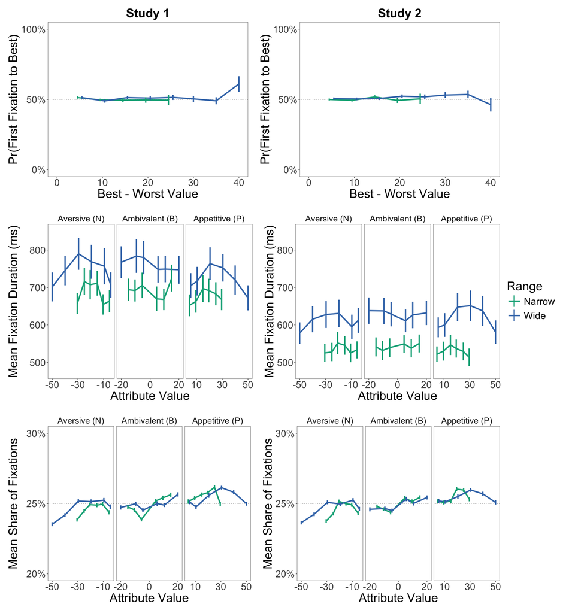

```r
# 3 rows x 2 columns (Study 1, Study 2).
fig_fix <- ((p_first[[1]] | p_first[[2]]) /
            (p_dur[[1]]   | p_dur[[2]]) /
            (p_share[[1]] | p_share[[2]])) +
  plot_layout(guides = "collect")

ggsave(file.path(fig_dir, "fixation_properties.pdf"), fig_fix, width = 2 * .figw, height = 3 * .figh)
fig_fix
```

## Regressions

One model per panel above, pooled across both studies with study crossed with every other predictor (Study 1 and Narrow are the reference levels, as in the psychometrics models). The first-fixation model uses uncorrelated random effects for the same reason as the RT model (the correlation went to -1). Fixation durations are right-skewed, so they are modeled on the log scale. The share model is a linear mixed model on the plotted quantity (share of the trial’s fixations); this replaces the negative binomial count model from the earlier notebooks, which had a degenerate dispersion estimate. Its subject intercept variance is exactly zero by construction (every subject’s shares average to 0.25 across the four boxes), so lme4 reports a singular fit there; the fixed effects are unaffected.

```r
if (RUN_REGRESSIONS) {
  d_trial <- pas      %>% filter(!is.na(FirstFixBest)) %>% mutate(Study = factor(Study))
  d_fix   <- long     %>% filter(FixDur > 0)           %>% mutate(Study = factor(Study))
  d_box   <- box_grid %>% mutate(Study = factor(Study))

  fit_first <- glmmTMB(
    FirstFixBest ~ Difficulty10 * WN * Study + (1 + Difficulty10 || Subject),
    data = d_trial, family = binomial
  )

  fit_dur <- lmer(
    log(FixDur) ~ fix_type * fix_value10 * WN * Study + (1 | Subject),
    data = d_fix
  )

  fit_share <- lmer(
    share ~ type * value10 * WN * Study + (1 | Subject),
    data = d_box
  )

  # One panel per model. Value effects on the share are a few thousandths, so
  # that panel gets four decimals.
  tab <- list(
    "Panel A: First Fixation to Best" = freq_columns(fit_first, "Frequentist (glmmTMB)"),
    "Panel B: log Fixation Duration"  = freq_columns(fit_dur,   "Frequentist (lme4)"),
    "Panel C: Share of Fixations"     = freq_columns(fit_share, "Frequentist (lme4)", digits = 4)
  )
  note <- sd_note(list("Panel A" = sds_freq(fit_first), "Panel B" = sds_freq(fit_dur),
                       "Panel C" = sds_freq(fit_share)))
  save_tex(tab, "fixation_properties", note)
}
```

## Text Output

The statistics quoted in the Fixation Process paragraphs of the paper.

```r
if (RUN_REGRESSIONS) {
  # Fixation duration by attribute type (log units, vs. appetitive) from the
  # pooled log-duration model, per study. Study 1 is the reference level, so
  # Study 2 adds the type x Study2 interaction. Evaluated at the model's
  # reference point (Narrow, value 0).
  out <- c()
  for (s in 1:2) {
    for (tt in c("N", "B")) {
      terms <- c(paste0("fix_type", tt), if (s == 2) paste0("fix_type", tt, ":Study2"))
      out <- c(out, paste0("$\\beta^{\\text{", tt, " - P}}_{\\text{Study ", s, "}} = ", fmt_coef(fit_dur, terms), "$"))
    }
  }
  save_text(paste(out, collapse = ", "), "fixdur_type")
}
```

```r
if (RUN_REGRESSIONS) {
  # Slope of log fixation duration on attribute value (per 10 points), per
  # type and study. P is the reference type and Study 1 the reference study,
  # so N and B add their type x value interaction and Study 2 adds the Study2
  # interactions.
  out <- c()
  for (s in 1:2) {
    for (tt in c("N", "B", "P")) {
      terms <- c("fix_value10",
                 if (tt != "P") paste0("fix_type", tt, ":fix_value10"),
                 if (s == 2) "fix_value10:Study2",
                 if (s == 2 && tt != "P") paste0("fix_type", tt, ":fix_value10:Study2"))
      out <- c(out, paste0("$\\beta^{\\text{value, ", tt, "}}_{\\text{Study ", s, "}} = ", fmt_coef(fit_dur, terms), "$"))
    }
  }
  save_text(paste(out, collapse = ", "), "fixdur_value")
}
```

```r
if (RUN_REGRESSIONS) {
  # Wide minus Narrow log fixation duration per study, from the pooled model
  # (Study 2 adds the WNWide:Study2 interaction).
  save_text(paste0(
    "$\\Delta^{\\text{Wide - Narrow}}_{\\text{Study 1}} = ", fmt_coef(fit_dur, "WNWide"), "$, ",
    "$\\Delta^{\\text{Wide - Narrow}}_{\\text{Study 2}} = ", fmt_coef(fit_dur, c("WNWide", "WNWide:Study2")), "$"
  ), "fixdur_range")
}
```

```r
if (RUN_REGRESSIONS) {
  # Slope of fixation share on attribute value (share per 10 value points),
  # per type and study, from the pooled share model. P is the reference type
  # and Study 1 the reference study, so N and B add their type x value
  # interaction and Study 2 adds the Study2 interactions. Four decimals,
  # since shares move by fractions of a percentage point.
  out <- c()
  for (s in 1:2) {
    for (tt in c("N", "B", "P")) {
      terms <- c("value10",
                 if (tt != "P") paste0("type", tt, ":value10"),
                 if (s == 2) "value10:Study2",
                 if (s == 2 && tt != "P") paste0("type", tt, ":value10:Study2"))
      out <- c(out, paste0("$\\beta^{\\text{value, ", tt, "}}_{\\text{Study ", s, "}} = ", fmt_coef(fit_share, terms, digits = 4), "$"))
    }
  }
  save_text(paste(out, collapse = ", "), "share_value")
}
```

```r
if (RUN_REGRESSIONS) {
  # Mean share of fixations per subject and attribute type (percentage
  # points), then paired t-tests P vs B and B vs N within each study.
  sh_subj <- box_grid %>%
    group_by(Study, Subject, type) %>%
    summarise(sh = 100 * mean(share), .groups = "drop") %>%
    pivot_wider(names_from = type, values_from = sh)
  out <- c()
  for (s in 1:2) {
    d <- sh_subj %>% filter(Study == s)
    out <- c(out,
      fmt_ttest(d$P, d$B, sup = "\\text{P - B}", sub = paste("Study", s), unit = "\\ \\text{pp}", paired = TRUE),
      fmt_ttest(d$B, d$N, sup = "\\text{B - N}", sub = paste("Study", s), unit = "\\ \\text{pp}", paired = TRUE))
  }
  save_text(paste(out, collapse = "; "), "share_type")
}
```